# 机器翻译与BPE

本节课我们将介绍一个机器翻译系统的主要流程和注意力机制的实现。然后，我们将介绍现在NLP任务中应用非常多的Byte Pair Encoding (BPE)技术，BPE通过统计方法将句子分解成subword unit被用以解决未登录词问题，在语言理解和语言生成问题中都有广泛的应用。

## 内容

- 机器翻译
  - Neural Machine Translation
  - Attention
- Byte Pair Encoding
  - 基于频率的BPE算法与Python简易实现
  - transformers

## 机器翻译

_（部分内容参考[PyTorch Tutorial](https://pytorch.org/tutorials/intermediate/seq2seq_translation_tutorial.html)实现）_

在这个项目中我们将实现一个简单的基于循环神经网络的机器翻译系统，用于英文到中文的翻译。当然，由于我们会使用玩具数据集(toy dataset)，翻译的效果是没有保证的。即便如此，我们会看到基于神经网络的模型强大的表达能力。需要注意的是，即便是现今最先进的机器翻译系统，在公开评测中还是无法超越人类的。比如，在WMT 2019的评测中，仅有Facebook-FAIR模型在英德翻译上取得了超越人类的效果，大多数模型在英德互译效果仅与人相当。<sup>[1]</sup>

**回顾**：在机器翻译中，序列到序列模型，首先将源语言编码为向量表示，然后根据该向量表示解码出目标语言的概率分布。解码过程中会利用注意力机制(attention)不断补充源语言的信息。最终句子的生成，可以由概率分布通过贪心算法(greedy search)得到，即每次只选择最可能的词作为输出；也可以通过柱搜索算法(beam search)得到，即每次保留最有可能的前几个子序列。

通过序列到序列(sequence-to-sequence)的模型框架，一个基础的机器翻译系统可以被简洁的实现，从代码的编写的角度可以被分为以下的构件：

- 数据处理
- 模型定义
- 训练循环
- 交互测试

```python
# 首先导入需要的工具包
import string
import re
import random

# 我们使用pytorch框架完成这个任务
import torch
import torch.nn as nn
import torch.optim as optim
import torch.nn.functional as F

# 计算设备对象，后续的操作中会使用该对象。如果CUDA可用的话，将使用GPU进行计算，否则使用CPU。
device = torch.device("cuda" if torch.cuda.is_available() else "cpu")

def reset_seed():
    random.seed(1211)
    torch.manual_seed(1211)
    torch.cuda.manual_seed(1211)
```

### 数据导入

我们使用的[玩具数据](https://www.manythings.org/anki/)中包含几万条平行中英句子对。我们需要将数据转换为计算机易于计算的形式，首先我们将对句子进行简单的清理，然后进行分词，最后将字符串转换为数字形式，最后一步的转换需要一个预先定义好的“词典”。

由于语言中的词数量是非常庞大的，实际中我们会控制词的数量在固定的范围内，常见的做法是根据训练集中的词频筛掉频率较低的词。原因一个是计算机的资源受限，另一个是对于统计机器学习系统来说低频数据无法提供足够可靠的统计信息，引入的噪音反而会加重过拟合的问题。

```python
SOS=0
EOS=1
MAX_LENGTH = 10
PREFIXS = (
    "i am ", "i m ",
    "he is", "he s ",
    "she is", "she s ",
    "you are", "you re ",
    "we are", "we re ",
    "they are", "they re "
)

def clean_latin_text(s):
    # 按空格分词
    s = s.lower().strip() # 小写并清除首尾空白字符
    s = re.sub(r"([.!?])", r" \1", s) # 标点前添加空格
    s = re.sub(r"[^a-zA-Z.!?]+", r" ", s) # 清除其它符号
    return s

def clean_zh_text(s):
    # 分字
    s = s.strip()
    s = ' '.join([char for char in s])
    return s


def filter_by_en(en, zh):
    # 只保留简单的句子
    return (len(en.split(' ')) < MAX_LENGTH and
        len(zh.split(' ')) < MAX_LENGTH and
        en.startswith(PREFIXS))

class Vocab:
    def __init__(self, name):
        self.name = name
        self.word2index = {'<SOS>': 0, '<EOS>': 1}
        self.word2count = {}
        self.index2word = {0: '<SOS>', 1: '<EOS>'}


    def __len__(self):
        return len(self.word2index)

    def add_sentence(self, sentence):

        for word in sentence.split(' '):
            self.add_word(word)

    def add_word(self, word):
        if word not in self.word2index:
            self.word2index[word] = len(self)
            self.word2count[word] = 1
            self.index2word[len(self)-1] = word
        else:
            self.word2count[word] += 1


def read_text(filename='05/cmn.txt'):
    print('reading text...')
    ens = []
    zhs = []

    vocab_en = Vocab('en')
    vocab_zh = Vocab('zh')

    # 用于繁简转换
    import zhconv

    with open(filename, 'r', encoding='utf8') as f:
        for line in f:
            parts = line.split('\t')
            en, zh = parts[0], parts[1]
            en = clean_latin_text(en)
            zh = zhconv.convert(zh, 'zh-cn')
            zh = clean_zh_text(zh)
            if filter_by_en(en, zh):
                ens.append(en)
                zhs.append(zh)
                vocab_en.add_sentence(en)
                vocab_zh.add_sentence(zh)

    print(f'Read {len(ens)} pairs')
    print(f'en: {len(vocab_en)} token types')
    print(f'zh: {len(vocab_zh)} token types')
    return ens, zhs, vocab_en, vocab_zh


ens, zhs, vocab_en, vocab_zh = read_text()
pairs = [[en, zh] for en, zh in zip(ens, zhs)]

reset_seed()
ex = random.choice(pairs)
print(ex)
```

```
reading text...
Read 1030 pairs
en: 884 token types
zh: 870 token types
['he s very angry with you .', '他 对 你 非 常 生 气 。']
```

### 模型架构

`torch`中的模型定义需要采用面向对象的基于继承的方式(继承`torch.nn.Module`类)完成。模型由编码器、解码器组成。我们在解码器中一并实现了基于全连接层的注意力机制。注意力的计算有很多种实现方式，但目标都是对两个向量计算一个分数。

一般而言，为了充分利用计算资源，模型计算会以批量的形式进行，即一次处理多个句子。但一次多个句子的处理时，需要额外考虑句长不同的问题。为了实现上的简易性，我们这里每次只处理一个句子。

```python
class EncoderRNN(nn.Module):
    def __init__(self, input_size, hidden_size):
        super(EncoderRNN, self).__init__() # 必须在添加参数前初始化基类
        self.hidden_size = hidden_size

        self.embedding = nn.Embedding(input_size, hidden_size)
        self.gru = nn.GRU(hidden_size, hidden_size, batch_first=True)

    def forward(self, input):
        # 输入单位为句子
        embedded = self.embedding(input)
        output, hidden = self.gru(embedded)
        return output, hidden


class AttnDecoderRNN(nn.Module):
    def __init__(self, hidden_size, output_size):
        super(AttnDecoderRNN, self).__init__()
        self.hidden_size = hidden_size
        self.output_size = output_size

        self.embedding = nn.Embedding(self.output_size, self.hidden_size)
        self.gru = nn.GRU(self.hidden_size, self.hidden_size)
        self.attn = nn.Linear(self.hidden_size * 2, 1)
        self.attn_combine = nn.Linear(self.hidden_size * 2, self.hidden_size)
        self.out = nn.Linear(self.hidden_size, self.output_size)

    def forward(self, input, hidden, encoder_outputs):
        # 输入单位为词
        # hidden should be [1, 1, hidden]
        # encoder_outputs shoud be [1, src_len, hidden]
        embedded = self.embedding(input).view(1, 1, -1)

        # [1, 1, hidden], [1, 1, hidden]
        output, hidden = self.gru(embedded, hidden)

        # [1, src_len]
        # 这里Attention的实现方法是，将解码器的隐状态与编码器的输出合并
        # 然后经过一个变化，输出每个位置对的分数
        attn_weights = self.attn(torch.cat([hidden.expand_as(encoder_outputs), encoder_outputs], dim=-1)).view(1, -1)
        attn_weights = F.softmax(attn_weights, dim=1)

        # [1, hidden] 这里是对编码器输出进行加权平均
        attn_applied = torch.mm(attn_weights, encoder_outputs[0])

        # [1, hidden]
        output = F.relu(self.attn_combine(torch.cat([output[0], attn_applied], dim=1)))

        output = self.out(output)

        return output, hidden, attn_weights
```

### 训练循环

为了显示表示数据结构并控制模型的行为，我们需要对原始文本加以变形，增加额外的控制符号，并转换成`torch`支持的tensor格式。

每步的训练可以分为：前向传播、反向传播、参数更新三个步骤。整体的训练是每步训练的循环，不同之处是每次会使用不同的数据进行训练。

```python
# 数字化句子对
def binarize_text(line, vocab):
    idxs =  [vocab.word2index[word] for word in line.split(' ')]
    return torch.tensor(idxs, dtype=torch.long, device=device).view(1, -1)

def string_text(tensor, vocab):
    idxs = tensor.tolist()[0]
    return ' '.join([vocab.index2word[idx] for idx in idxs])

def tensor_from_pair(pair):
    return binarize_text(pair[0] + ' <EOS>', vocab_en), binarize_text('<SOS> ' + pair[1] + ' <EOS>', vocab_zh)

def recover_from_tensor(pair):
    return string_text(pair[0], vocab_en), string_text(pair[1], vocab_zh)

# 注意，为了使得模型更好的捕获控制信号，我们会额外添加<SOS>和<EOS>符号
print(tensor_from_pair(ex))
print(recover_from_tensor(tensor_from_pair(ex)))
```

```
(tensor([[ 14,  15,  86, 128, 319,  51,   5,   1]]), tensor([[  0,  19,  28,  76, 187, 188,   6, 194,   5,   1]]))
('he s very angry with you . <EOS>', '<SOS> 他 对 你 非 常 生 气 。 <EOS>')
```

```python
# 每个训练步骤，由前向传播、反向传播和参数更新构成
def train_step(input_tensor, target_tensor,
          encoder, decoder,
          encoder_optimizer, decoder_optimizer,
          criterion):

    # optimizer
    encoder_optimizer.zero_grad()
    decoder_optimizer.zero_grad()

    input_length = input_tensor.size(1)
    target_length = target_tensor.size(1)

    # encode [1, src_len, hidden_size], [1, 1, hidden_size]
    encoder_outputs, encoder_hidden = encoder(input_tensor)

    # decode
    decoder_outputs = []
    decoder_hidden = encoder_hidden # [1, 1, hidden_size]

    # Teacher forcing
    for di in range(target_length - 1):
        # [1, out], [1, 1, hidden], [1, src_len]
        decoder_output, decoder_hidden, decoder_attention = decoder(
            target_tensor[:, di], decoder_hidden, encoder_outputs)
        decoder_outputs.append(decoder_output)

    decoder_outputs = torch.stack(decoder_outputs, dim=1)[0] # [tgt_len, vocab]
    decoder_targets = target_tensor[0, 1:] # [tgt_len]
    loss = criterion(decoder_outputs, decoder_targets)
    # backprop
    loss.backward()

    # update
    encoder_optimizer.step()
    decoder_optimizer.step()

    return loss.item() / (target_length - 1)
```

```python
# 整个训练的循环，我们训练固定的次数
def train(encoder, decoder, n_iters, print_every=100,
               learning_rate=0.001):
    reset_seed()
    print_loss_total = 0  # Reset every print_every

    # 初始化优化器和优化目标
    encoder_optimizer = optim.Adam(encoder.parameters(), lr=learning_rate)
    decoder_optimizer = optim.Adam(decoder.parameters(), lr=learning_rate)
    criterion = nn.CrossEntropyLoss()

    for iter in range(1, n_iters + 1):
        training_pair = tensor_from_pair(random.choice(pairs)) # 随机选择一个句子对进行训练
        input_tensor = training_pair[0]
        target_tensor = training_pair[1]

        loss = train_step(input_tensor, target_tensor, encoder,
                     decoder, encoder_optimizer, decoder_optimizer, criterion)
        print_loss_total += loss

        if iter % print_every == 0:
            print_loss_avg = print_loss_total / print_every
            print_loss_total = 0
            print(f'| iter {iter:03d}/{n_iters:03d} | loss {print_loss_avg:.4f}')
```

我们实例化一个隐层大小为128的NMT模型，并使用`train`函数进行训练。

```python
reset_seed()
hidden_size = 128

encoder1 = EncoderRNN(len(vocab_en), hidden_size).to(device)
attn_decoder1 = AttnDecoderRNN(hidden_size, len(vocab_zh)).to(device)

train(encoder1, attn_decoder1, 10000)
```

```
| iter 100/10000 | loss 0.6155
| iter 200/10000 | loss 0.4920
| iter 300/10000 | loss 0.4731
| iter 400/10000 | loss 0.4806
| iter 500/10000 | loss 0.4508
| iter 600/10000 | loss 0.4479
| iter 700/10000 | loss 0.4428
| iter 800/10000 | loss 0.4267
| iter 900/10000 | loss 0.4364
| iter 1000/10000 | loss 0.3911
| iter 1100/10000 | loss 0.3953
| iter 1200/10000 | loss 0.3704
| iter 1300/10000 | loss 0.3774
| iter 1400/10000 | loss 0.3634
| iter 1500/10000 | loss 0.3669
| iter 1600/10000 | loss 0.3461
| iter 1700/10000 | loss 0.3814
| iter 1800/10000 | loss 0.3315
| iter 1900/10000 | loss 0.3599
| iter 2000/10000 | loss 0.3145
| iter 2100/10000 | loss 0.2989
| iter 2200/10000 | loss 0.2999
| iter 2300/10000 | loss 0.2985
| iter 2400/10000 | loss 0.2761
| iter 2500/10000 | loss 0.2606
| iter 2600/10000 | loss 0.2730
| iter 2700/10000 | loss 0.2689
| iter 2800/10000 | loss 0.2773
| iter 2900/10000 | loss 0.2316
| iter 3000/10000 | loss 0.2392
| iter 3100/10000 | loss 0.2273
| iter 3200/10000 | loss 0.2251
| iter 3300/10000 | loss 0.2127
| iter 3400/10000 | loss 0.2012
| iter 3500/10000 | loss 0.2091
| iter 3600/10000 | loss 0.2003
| iter 3700/10000 | loss 0.2022
| iter 3800/10000 | loss 0.1855
| iter 3900/10000 | loss 0.1760
| iter 4000/10000 | loss 0.1535
```

[output cut: 45 more lines]

```
| iter 8600/10000 | loss 0.0442
| iter 8700/10000 | loss 0.0377
| iter 8800/10000 | loss 0.0491
| iter 8900/10000 | loss 0.0299
| iter 9000/10000 | loss 0.0299
| iter 9100/10000 | loss 0.0343
| iter 9200/10000 | loss 0.0363
| iter 9300/10000 | loss 0.0283
| iter 9400/10000 | loss 0.0409
| iter 9500/10000 | loss 0.0218
| iter 9600/10000 | loss 0.0259
| iter 9700/10000 | loss 0.0210
| iter 9800/10000 | loss 0.0272
| iter 9900/10000 | loss 0.0248
| iter 10000/10000 | loss 0.0385
```

### 交互测试

在测试中，由于我们无法获得标准的输入，所以训练中使用的teacher forcing，即每次解码时都输入“正确”的词的做法不再可行。我们这里采用的是基于贪心解码的方式，每次将预测出来的最有可能的词作为新解码器输入。这个生成的终止条件是，生成符号，或者达到约定的最长的长度。

```python
def inference(encoder, decoder, sentence):
    with torch.no_grad():
        input_tensor = binarize_text(clean_latin_text(sentence) + ' <EOS>', vocab_en)
        input_length = input_tensor.size()[1]

        # encode [1, src_len, hidden_size], [1, 1, hidden_size]
        encoder_outputs, encoder_hidden = encoder(input_tensor)

        # decode
        decoder_words = ['<SOS>']
        decoder_hidden = encoder_hidden # [1, 1, hidden_size]
        decoder_attentions = []

        for _ in range(MAX_LENGTH):
            last_word = decoder_words[-1]
            last_word_idx = vocab_zh.word2index[last_word]
            decoder_input = torch.tensor([[last_word_idx]], device=device)

            # [1, out], [1, 1, hidden], [1, src_len]
            decoder_output, decoder_hidden, decoder_attention = decoder(
                decoder_input, decoder_hidden, encoder_outputs)
            decoder_attentions.append(decoder_attention)

            word_idx = torch.argmax(decoder_output[0])
            word = vocab_zh.index2word[word_idx.item()]
            decoder_words.append(word)
            if word == '<EOS>':
                break

        # [tgt_len, src_len]
        decoder_attentions = torch.cat(decoder_attentions, dim=0).tolist()

        return decoder_words, decoder_attentions
```

```python
def evaluate_randomly(encoder, decoder, n=10):
    # 随机选择几个句子查看学习的效果
    reset_seed()
    for i in range(n):
        pair = random.choice(pairs)
        print('>', pair[0])
        print('=', pair[1])
        output_words, attentions = inference(encoder, decoder, pair[0])
        output_sentence = ' '.join(output_words[1:])
        print('<', output_sentence)
        print('')

evaluate_randomly(encoder1, attn_decoder1)
```

```
> he s very angry with you .
= 他 对 你 非 常 生 气 。
< 他 对 你 非 常 生 气 。 <EOS>

> you are responsible for the result .
= 你 要 对 结 果 负 责 。
< 你 要 对 结 果 负 责 。 <EOS>

> he is to come to my house tonight .
= 他 今 晚 会 来 我 家 。
< 他 会 来 他 会 来 我 家 。 <EOS>

> they re digging a hole .
= 他 们 正 在 挖 一 个 洞 。
< 他 们 正 在 聊 天 。 <EOS>

> i m hoping that ll happen .
= 我 希 望 那 会 发 生 。
< 我 希 望 那 会 发 生 。 <EOS>

> i m free tonight .
= 我 今 晚 有 空 。
< 我 渴 定 。 <EOS>

> they are very big .
= 他 们 非 常 大 。
< 他 们 非 常 大 。 <EOS>

> i am playing the piano now .
= 我 现 在 正 在 弹 钢 琴 。
< 我 现 在 正 在 弹 钢 琴 。 <EOS>

> i m not too smart .
= 我 不 太 聪 明 。
< 我 不 太 聪 明 。 <EOS>

> i m married .
= 我 已 婚 。
< 我 已 婚 。 <EOS>
```

```
input = i m ok .
output = <SOS> 我 没 事 。 <EOS>
```

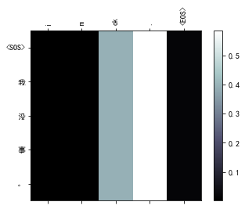

```
input = he s lazy .
output = <SOS> 他 很 懒 。 <EOS>
```

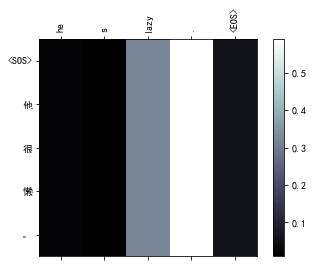

```
input = i m sorry .
output = <SOS> 对 不 起 。 <EOS>
```

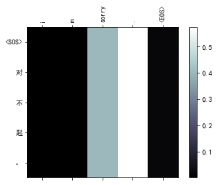

```
input = i m lazy .
output = <SOS> 我 很 懒 。 <EOS>
```

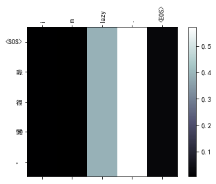

```python
# 使用matplotlib进行可视化，纵坐标为目标的输入词，横坐标为源语言句子

import matplotlib.pyplot as plt
plt.rcParams['font.sans-serif'] = ['SimHei']
import matplotlib.ticker as ticker

def show_attention(input_sentence, output_words, attentions):
    # Set up figure with colorbar
    fig = plt.figure()
    ax = fig.add_subplot(111)
    cax = ax.matshow(attentions, cmap='bone')
    fig.colorbar(cax)

    # Set up axes
    ax.set_xticklabels([''] + input_sentence.split(' ') +
                       ['<EOS>'], rotation=90)
    ax.set_yticklabels([''] + output_words)

    # Show label at every tick
    ax.xaxis.set_major_locator(ticker.MultipleLocator(1))
    ax.yaxis.set_major_locator(ticker.MultipleLocator(1))

    plt.show()

def evaluate_and_show_attention(input_sentence):
    output_words, attentions = inference(
        encoder1, attn_decoder1, input_sentence)
    print('input =', input_sentence)
    print('output =', ' '.join(output_words))
    show_attention(input_sentence, output_words, attentions)

pairs = [[en, zh] for en, zh in zip(ens, zhs)]
evaluate_and_show_attention(pairs[0][0])
evaluate_and_show_attention(pairs[10][0])
evaluate_and_show_attention(pairs[20][0])
evaluate_and_show_attention('i m lazy .')
```

## BPE

Byte Pair Encoding，顾名思义是根据Byte Pair对进行编码，原本是一种通用的数据编码与压缩方法。

> Byte pair encoding or digram coding is a simple form of data compression in which the most common pair of consecutive bytes of data is replaced with a byte that does not occur within that data. A table of the replacements is required to rebuild the original data. The algorithm was *first described publicly* by Philip Gage in a *February 1994* article "A New Algorithm for Data Compression" in the C Users Journal.

在NLP的应用中，BPE技术得到进一步扩展，从字符序列开始，每次基于一对字符串编码文本，即将最常出现的相邻的字符串拼合为新的字符串，循环往复直到结束。

编码后的文本是被称为subword unit的序列。subword unit是介于字符与词之间的一种单元。类似语言学中word与morpheme的级别关系：词素是构成词的要素，是语言中最小单位的音义结合体；而词是语言中能够独立运用的最小单位。但subword unit与的最大的区别是subword unit是基于数据统计信息划分的，不一定具有原子性的含义。比如，“葡萄”这个短语既是词语也是词素，但BPE编码有可能将其编码为“葡”和“萄”。

BPE可以有效的解决按词进行文本处理导致的未登录词(out-of-vocabulary, OOV)问题。现有的算法都依赖于固定大小的词汇表来处理文本。基于词为单位进行编码虽然逻辑上最为合理，但在实践中有很多问题。比如词表爆炸的问题，根据Zipf定律，语言中大部分的词是低频词，如果把只出现一两次的词都算到词表中，词表会巨大无比，而且基于统计的模型对于低频词是捕获不到多少信息的。未登录词是指那些没有在训练语言中出现过的词，算法根本就无法获得其统计信息的，但真实文本中又往往经常出现。现在解决OOV有很多方法，比如基于字符/字编码和字符词汇联合编码等。BPE通过一个有限的词表，可以编码所有的文本，同时保留了一定词语结构上的信息。

### 基于频率的BPE算法与Python简易实现

Sennrich et al. (2016)于ACL 2016年提出了使用BPE在机器翻译中的构建subword词表。BPE的应用分为两个过程，首先是学习BPE的组合，其次是在新文本上应用BPE获得subword的序列。

学习算法流程如下：

1. 准备一个足够大的训练数据，用于学习BPE
2. 定义一个理想的subword词典大小
3. 将“词”切成字符片段，并在每个词后面附加元符号“</w>”表示词结尾，然后补充词的频率，例如“low”的频率为5，我们将记录这样一条记录  
   "l o w </w>": 5
4. 选择最高频率的“基本单元”对组成一个新的subword，并记录一个“组合”
5. 重复第4步，直到达到预定义的词典大小，或者下一个最高频率对的频率为1

```python
import re, collections

from IPython.display import display, Markdown
def show_bold(string):
    display(Markdown(f'**{string}**'))

def show_heading(string, level=4):
    display(Markdown('#'*level + ' ' + string))


def get_stats(vocab):
    """Compute frequencies of adjacent pairs of symbols."""
    pairs = collections.defaultdict(int)
    for word, freq in vocab.items():
        symbols = word.split()
        for i in range(len(symbols)-1):
            pairs[symbols[i],symbols[i+1]] += freq
    return pairs

def merge_vocab(pair, v_in):
    v_out = {}
    bigram = re.escape(' '.join(pair))
    p = re.compile(r'(?<!\S)' + bigram + r'(?!\S)')
    for word in v_in:
        w_out = p.sub(''.join(pair), word)
        v_out[w_out] = v_in[word]
    return v_out
```

```python
train_data = {
    'l o w </w>': 5,
    'l o w e r </w>': 2,
    'n e w e s t </w>': 6,
    'w i d e s t </w>': 3
}

bpe_codes = {}
bpe_codes_reverse = {}

num_merges = 10

for i in range(num_merges):
    show_bold(f"Iteration {i+1}")
    pairs = get_stats(train_data)
    best = max(pairs, key=pairs.get)
    train_data = merge_vocab(best, train_data)

    bpe_codes[best] = i
    bpe_codes_reverse[best[0] + best[1]] = best

    print("new merge: {}".format(best))
    print("train data: {}".format(train_data))
```

**Iteration 1**

```
new merge: ('e', 's')
train data: {'l o w </w>': 5, 'l o w e r </w>': 2, 'n e w es t </w>': 6, 'w i d es t </w>': 3}
```

**Iteration 2**

```
new merge: ('es', 't')
train data: {'l o w </w>': 5, 'l o w e r </w>': 2, 'n e w est </w>': 6, 'w i d est </w>': 3}
```

**Iteration 3**

```
new merge: ('est', '</w>')
train data: {'l o w </w>': 5, 'l o w e r </w>': 2, 'n e w est</w>': 6, 'w i d est</w>': 3}
```

**Iteration 4**

```
new merge: ('l', 'o')
train data: {'lo w </w>': 5, 'lo w e r </w>': 2, 'n e w est</w>': 6, 'w i d est</w>': 3}
```

**Iteration 5**

```
new merge: ('lo', 'w')
train data: {'low </w>': 5, 'low e r </w>': 2, 'n e w est</w>': 6, 'w i d est</w>': 3}
```

**Iteration 6**

```
new merge: ('n', 'e')
train data: {'low </w>': 5, 'low e r </w>': 2, 'ne w est</w>': 6, 'w i d est</w>': 3}
```

**Iteration 7**

```
new merge: ('ne', 'w')
train data: {'low </w>': 5, 'low e r </w>': 2, 'new est</w>': 6, 'w i d est</w>': 3}
```

**Iteration 8**

```
new merge: ('new', 'est</w>')
train data: {'low </w>': 5, 'low e r </w>': 2, 'newest</w>': 6, 'w i d est</w>': 3}
```

**Iteration 9**

```
new merge: ('low', '</w>')
train data: {'low</w>': 5, 'low e r </w>': 2, 'newest</w>': 6, 'w i d est</w>': 3}
```

**Iteration 10**

```
new merge: ('w', 'i')
train data: {'low</w>': 5, 'low e r </w>': 2, 'newest</w>': 6, 'wi d est</w>': 3}
```

应用BPE的流程如下：

1. 将“词”切成字符片段，并在每个词后面附加元符号“</w>”表示词结尾
2. 查找在“组合”表中频率最高的相邻单元对，并合并
3. 重复2直到只剩一个基本单元或者剩下的单元对都不在组合表中

```python
def get_pairs(word):
    """Return set of symbol pairs in a word.
    Word is represented as a tuple of symbols (symbols being variable-length strings).
    """
    pairs = set()
    prev_char = word[0]
    for char in word[1:]:
        pairs.add((prev_char, char))
        prev_char = char
    return pairs


def encode(orig):
    """Encode word based on list of BPE merge operations, which are applied consecutively"""

    word = tuple(orig) + ('</w>',)
    print("word split into characters: {}".format(word))

    pairs = get_pairs(word)

    if not pairs:
        return orig

    iteration = 0
    while True:
        iteration += 1
        show_bold(f"Iteration {iteration}:")

        print(f"bigrams in the word: {pairs}")
        bigram = min(pairs, key = lambda pair: bpe_codes.get(pair, float('inf')))
        print(f"candidate for merging: {bigram}")
        if bigram not in bpe_codes:
            print("Candidate not in BPE merges, algorithm stops.")
            break
        first, second = bigram
        new_word = []
        i = 0
        while i < len(word):
            try:
                j = word.index(first, i)
                new_word.extend(word[i:j])
                i = j
            except:
                new_word.extend(word[i:])
                break

            if word[i] == first and i < len(word)-1 and word[i+1] == second:
                new_word.append(first+second)
                i += 2
            else:
                new_word.append(word[i])
                i += 1
        new_word = tuple(new_word)
        word = new_word
        print(f"word after merging: {word}")
        if len(word) == 1:
            break
        else:
            pairs = get_pairs(word)

    # don't print end-of-word symbols
    if word[-1] == '</w>':
        word = word[:-1]
    elif word[-1].endswith('</w>'):
        word = word[:-1] + (word[-1].replace('</w>',''),)

    return word
```

例子：lowest不在训练数据中，但low于est都在subword表中

```python
encode("lowest")
```

```
word split into characters: ('l', 'o', 'w', 'e', 's', 't', '</w>')
```

**Iteration 1:**

```
bigrams in the word: {('o', 'w'), ('t', '</w>'), ('l', 'o'), ('s', 't'), ('w', 'e'), ('e', 's')}
candidate for merging: ('e', 's')
word after merging: ('l', 'o', 'w', 'es', 't', '</w>')
```

**Iteration 2:**

```
bigrams in the word: {('o', 'w'), ('t', '</w>'), ('es', 't'), ('l', 'o'), ('w', 'es')}
candidate for merging: ('es', 't')
word after merging: ('l', 'o', 'w', 'est', '</w>')
```

**Iteration 3:**

```
bigrams in the word: {('l', 'o'), ('w', 'est'), ('est', '</w>'), ('o', 'w')}
candidate for merging: ('est', '</w>')
word after merging: ('l', 'o', 'w', 'est</w>')
```

**Iteration 4:**

```
bigrams in the word: {('w', 'est</w>'), ('l', 'o'), ('o', 'w')}
candidate for merging: ('l', 'o')
word after merging: ('lo', 'w', 'est</w>')
```

**Iteration 5:**

```
bigrams in the word: {('w', 'est</w>'), ('lo', 'w')}
candidate for merging: ('lo', 'w')
word after merging: ('low', 'est</w>')
```

**Iteration 6:**

```
bigrams in the word: {('low', 'est</w>')}
candidate for merging: ('low', 'est</w>')
Candidate not in BPE merges, algorithm stops.
```

```
('low', 'est')
```

Sennrich et al. (2016)提出的BPE是目前翻译中应用最为广泛的subword拆分方式。NMT模型擅长翻译文本的流畅性，但在未登录词上精度较SMT模型弱不少，特别是中文（基于词的模型）、屈折形式复杂的语言（德语、西班牙语）。通过BPE，可以大幅降低未登录词的数量，提升NMT模型的可用性。在一些语言中甚至可以将未登录词数量降为0，比如英语。但对于中文来说，还是会有少量未登录词。一个现有的研究表明，在中英翻译中，中文词个数有20多万，使用常用的3万大小的词表，会出现17万的未登录词；而使用3万大小的BPE词表，可以将未登录词数量将为5百多；而英语10万词可以用不到3万的BPE完全表示。

Sennrich et al. (2016)开源了代码，项目名为subword-nmt。同时，也有其它的项目复现了该算法，比如fastBPE等。该BPE方法也被用于GPT、RoBERTa等预训练模型。在很多任务上，是否使用BPE在模型结果上有天壤之别。有很大的可能，在基线模型上使用BPE可以超过一系列基线模型的改进。

### 基于语言模型的BPE

#### WordPiece

WordPiece是另一种切分方法，于BPE类似。Schuster and Nakajima在2012年提出，来解决日语和汉语的语音识别问题。

流程如下：

1. 准备一个足够大的训练数据
2. 定义一个理想的subword词典大小
3. 将“词”切成字符片段
4. 根据3的结果学习一个语言模型
5. 选择cib所有可能的新词中能使训练数据似然增高最大的那个词，加入subword词典，并记录一个“组合”
6. 重复第5步，直到达到预定义的词典大小，或者似然增高低于某个阈值

#### Unigram Language Model

Kudo (2018)于ACL 2018提出的另一种方法，借助Unigram Language Model，基于subword出现独立的假设。主要使为了解决subword切分歧义的问题。比如“bookkeeper”这个词可能被拆为“book keeper”或者“book keep er”，BPE采用贪心的方式，每次组合最高频率的单元对，但组合结果不一定是最合理的。Kudo引入Unigram Language Model对组合进行正则化，期望获得困惑度最小的subword序列。流程不再赘述。

BPE有很广泛的应用，在词向量学习中(fasttext)、语言理解(BERT等)、语言生成(GPT等)，是一项实用、有效的技术。

### Transformers

`transformers`工具包提供的预训练模型中，BERT使用的Tokenzier是基于WordPiece的，GPT、XLM、XLNet、RoBERTa是基于BPE的，TransformerXL没有使用subword切分。我们可以通过调用工具包提供的方法来复用已经训练好的subword切分方式。需要注意的是BPE方法一般均需要提前进行基本的tokenization。`transformers`中的Tokenizer首先会执行特定的tokenization、然后应用BPE，同时不同模型BPE的训练语料也不完全相同，因而即便使用了同一种BPE算法，对一个句子的编码很可能不一致。比如：

- BERT使用的tokenization仅处理标点
- GPT使用的tokenization是首先ftfy正规化文本、然后使用spaCy的tokenizer
- XLM使用的tokenization是机器翻译工具包MOSES提供的

下面我们比较一下几种方法的不同点。

```python
from transformers import (BertTokenizer, OpenAIGPTTokenizer,
    TransfoXLTokenizer, GPT2Tokenizer,  XLMTokenizer, XLNetTokenizer, RobertaTokenizer)


tokenizers ={
    'bert-base-cased': BertTokenizer.from_pretrained('bert-base-cased'),
    'bert-base-multilingual-cased': BertTokenizer.from_pretrained('bert-base-multilingual-cased'),
    'bert-base-chinese': BertTokenizer.from_pretrained('bert-base-chinese'),
    'gpt': OpenAIGPTTokenizer.from_pretrained('openai-gpt'),
    'gpt2': GPT2Tokenizer.from_pretrained('gpt2'),
    'transformerxl': TransfoXLTokenizer.from_pretrained('transfo-xl-wt103'),
    'xlnet-base-cased':  XLNetTokenizer.from_pretrained('xlnet-base-cased'),
    'xlm-mlm-en': XLMTokenizer.from_pretrained('xlm-mlm-en-2048'),
    'xlm-mlm-tlm-xnli15-1024': XLMTokenizer.from_pretrained('xlm-mlm-tlm-xnli15-1024'),
    'roberta-base': RobertaTokenizer.from_pretrained('roberta-base'),
}
```

```python
def transformers_tokenize_sentence(sentence):
    print(f'sentence:\n{sentence}')
    print()
    for name, tok in tokenizers.items():
        print(f'{name}:\n{tok.tokenize(sentence)}')
        print()
        print(f'{name} (recover):\n{tok.decode(tok.encode(sentence))}')
        print()
    print()
```

```python
texts = [
    'In a shocking finding, scientist discovered a herd of unicorns living in a remote, previously unexplored valley, in the Andes Mountains. Even more surprising to the researchers was the fact that the unicorns spoke perfect English.',
    '独角兽是一种传说生物，形象通常为头上长有独角的白马。现实世界中，独角鲸也许是这个神话动物的原型，不过独角鲸生活在遥远的北冰洋的深海而不是山川草原。生活在陆地上的犀牛，前额也有一只尖利的角，可惜相貌差距甚远。也有人说，独角兽其实就是已灭绝的板齿犀，亦称为西伯利亚独角兽，大约在2.9万年前灭绝。',
    'El unicornio es una criatura mitológica representada habitualmente como un caballo blanco con patas de antílope, ojos y barba de chivo y un cuerno en la frente.',
    "La licorne, parfois nommée unicorne, est une créature légendaire à corne unique. Son origine, controversée, résulte de multiples influences, en particulier de descriptions d'animaux tels que le rhinocéros et l'antilope, issues de récits d'explorateurs.",
    'Das Einhorn (lat. unicornis, griech. monókeros) ist ein Fabelwesen von Pferde- oder Ziegengestalt mit einem geraden Horn auf der Stirnmitte.',
    'Miley Cyrus was caught shoplifting from Abercrombie and Fitch on Hollywood Boulevard today.',
    'We’ve trained a large language model called GPT-2 that generates realistic paragraphs of text, while also exhibiting zero shot generalization on tasks like machine translation, question answering, reading comprehension, and summarization - problems usually approached by using training datasets and models designed explicitly for these tasks.',
    'こんにちは世界。',
    '你好，世界。',
    'Hello, world.',

]
```

```python
for i, sent in enumerate(texts):
    show_bold(f'Sentence {i}')
    transformers_tokenize_sentence(sent)
```

**Sentence 0**

```
sentence:
In a shocking finding, scientist discovered a herd of unicorns living in a remote, previously unexplored valley, in the Andes Mountains. Even more surprising to the researchers was the fact that the unicorns spoke perfect English.

bert-base-cased:
['In', 'a', 'shocking', 'finding', ',', 'scientist', 'discovered', 'a', 'herd', 'of', 'un', '##icorn', '##s', 'living', 'in', 'a', 'remote', ',', 'previously', 'une', '##x', '##p', '##lore', '##d', 'valley', ',', 'in', 'the', 'Andes', 'Mountains', '.', 'Even', 'more', 'surprising', 'to', 'the', 'res…

bert-base-cased (recover):
In a shocking finding, scientist discovered a herd of unicorns living in a remote, previously unexplored valley, in the Andes Mountains. Even more surprising to the researchers was the fact that the unicorns spoke perfect English.

bert-base-multilingual-cased:
['In', 'a', 'shock', '##ing', 'finding', ',', 'scientist', 'discovered', 'a', 'her', '##d', 'of', 'unico', '##rns', 'living', 'in', 'a', 'remote', ',', 'previously', 'une', '##x', '##plo', '##red', 'valley', ',', 'in', 'the', 'Andes', 'Mountains', '.', 'Even', 'more', 'sur', '##pris', '##ing', 'to',…

bert-base-multilingual-cased (recover):
In a shocking finding, scientist discovered a herd of unicorns living in a remote, previously unexplored valley, in the Andes Mountains. Even more surprising to the researchers was the fact that the unicorns spoke perfect English.

bert-base-chinese:
['[UNK]', 'a', 'sh', '##ock', '##ing', 'find', '##ing', ',', 'sci', '##ent', '##ist', 'di', '##sco', '##ver', '##ed', 'a', 'her', '##d', 'of', 'u', '##nic', '##or', '##ns', 'living', 'in', 'a', 're', '##mo', '##te', ',', 'previous', '##ly', 'u', '##ne', '##xp', '##lor', '##ed', 'valley', ',', 'in', …

bert-base-chinese (recover):
[UNK] a shocking finding, scientist discovered a herd of unicorns living in a remote, previously unexplored valley, in the [UNK] [UNK]. [UNK] more surprising to the researchers was the fact that the unicorns spoke perfect [UNK].

gpt:
['in</w>', 'a</w>', 'shocking</w>', 'finding</w>', ',</w>', 'scientist</w>', 'discovered</w>', 'a</w>', 'herd</w>', 'of</w>', 'unicorns</w>', 'living</w>', 'in</w>', 'a</w>', 'remote</w>', ',</w>', 'previously</w>', 'unex', 'pl', 'ored</w>', 'valley</w>', ',</w>', 'in</w>', 'the</w>', 'and', 'es</w>…

gpt (recover):
in a shocking finding, scientist discovered a herd of unicorns living in a remote, previously unexplored valley, in the andes mountains. even more surprising to the researchers was the fact that the unicorns spoke perfect english.

gpt2:
['In', 'Ġa', 'Ġshocking', 'Ġfinding', ',', 'Ġscientist', 'Ġdiscovered', 'Ġa', 'Ġherd', 'Ġof', 'Ġunic', 'orns', 'Ġliving', 'Ġin', 'Ġa', 'Ġremote', ',', 'Ġpreviously', 'Ġunexpl', 'ored', 'Ġvalley', ',', 'Ġin', 'Ġthe', 'ĠAnd', 'es', 'ĠMountains', '.', 'ĠEven', 'Ġmore', 'Ġsurprising', 'Ġto', 'Ġthe', 'Ġr…

gpt2 (recover):
In a shocking finding, scientist discovered a herd of unicorns living in a remote, previously unexplored valley, in the Andes Mountains. Even more surprising to the researchers was the fact that the unicorns spoke perfect English.

transformerxl:
['In', 'a', 'shocking', 'finding,', 'scientist', 'discovered', 'a', 'herd', 'of', 'unicorns', 'living', 'in', 'a', 'remote,', 'previously', 'unexplored', 'valley,', 'in', 'the', 'Andes', 'Mountains.', 'Even', 'more', 'surprising', 'to', 'the', 'researchers', 'was', 'the', 'fact', 'that', 'the', 'uni…

transformerxl (recover):
In a shocking <unk> scientist discovered a herd of unicorns living in a <unk> previously unexplored <unk> in the Andes <unk> Even more surprising to the researchers was the fact that the unicorns spoke perfect <unk>

xlnet-base-cased:
['▁In', '▁a', '▁shocking', '▁finding', ',', '▁scientist', '▁discovered', '▁a', '▁her', 'd', '▁of', '▁', 'uni', 'corn', 's', '▁living', '▁in', '▁a', '▁remote', ',', '▁previously', '▁un', 'exp', 'lor', 'ed', '▁valley', ',', '▁in', '▁the', '▁And', 'es', '▁Mountains', '.', '▁Even', '▁more', '▁surprising…

xlnet-base-cased (recover):
In a shocking finding, scientist discovered a herd of unicorns living in a remote, previously unexplored valley, in the Andes Mountains. Even more surprising to the researchers was the fact that the unicorns spoke perfect English.

xlm-mlm-en:
['in</w>', 'a</w>', 'shocking</w>', 'finding</w>', ',</w>', 'scientist</w>', 'discovered</w>', 'a</w>', 'herd</w>', 'of</w>', 'unic', 'orns</w>', 'living</w>', 'in</w>', 'a</w>', 'remote</w>', ',</w>', 'previously</w>', 'un', 'explored</w>', 'valley</w>', ',</w>', 'in</w>', 'the</w>', 'andes</w>', '…

xlm-mlm-en (recover):
in a shocking finding, scientist discovered a herd of unicorns living in a remote, previously unexplored valley, in the andes mountains. even more surprising to the researchers was the fact that the unicorns spoke perfect english.

xlm-mlm-tlm-xnli15-1024:
['in</w>', 'a</w>', 'sho', 'cking</w>', 'finding</w>', ',</w>', 'sci', 'ent', 'ist</w>', 'discovered</w>', 'a</w>', 'her', 'd</w>', 'of</w>', 'unic', 'or', 'ns</w>', 'living</w>', 'in</w>', 'a</w>', 'remo', 'te</w>', ',</w>', 'previ', 'ously</w>', 'un', 'explo', 'red</w>', 'valley</w>', ',</w>', 'in…

xlm-mlm-tlm-xnli15-1024 (recover):
in a shocking finding, scientist discovered a herd of unicorns living in a remote, previously unexplored valley, in the andes mountains. even more surprising to the researchers was the fact that the unicorns spoke perfect english.

roberta-base:
['In', 'Ġa', 'Ġshocking', 'Ġfinding', ',', 'Ġscientist', 'Ġdiscovered', 'Ġa', 'Ġherd', 'Ġof', 'Ġunic', 'orns', 'Ġliving', 'Ġin', 'Ġa', 'Ġremote', ',', 'Ġpreviously', 'Ġunexpl', 'ored', 'Ġvalley', ',', 'Ġin', 'Ġthe', 'ĠAnd', 'es', 'ĠMountains', '.', 'ĠEven', 'Ġmore', 'Ġsurprising', 'Ġto', 'Ġthe', 'Ġr…

roberta-base (recover):
In a shocking finding, scientist discovered a herd of unicorns living in a remote, previously unexplored valley, in the Andes Mountains. Even more surprising to the researchers was the fact that the unicorns spoke perfect English.
```

**Sentence 1**

```
sentence:
独角兽是一种传说生物，形象通常为头上长有独角的白马。现实世界中，独角鲸也许是这个神话动物的原型，不过独角鲸生活在遥远的北冰洋的深海而不是山川草原。生活在陆地上的犀牛，前额也有一只尖利的角，可惜相貌差距甚远。也有人说，独角兽其实就是已灭绝的板齿犀，亦称为西伯利亚独角兽，大约在2.9万年前灭绝。

bert-base-cased:
['[UNK]', '[UNK]', '[UNK]', '[UNK]', '一', '[UNK]', '[UNK]', '[UNK]', '生', '[UNK]', '，', '[UNK]', '[UNK]', '[UNK]', '[UNK]', '[UNK]', '[UNK]', '上', '[UNK]', '[UNK]', '[UNK]', '[UNK]', '[UNK]', '白', '[UNK]', '。', '[UNK]', '[UNK]', '[UNK]', '[UNK]', '中', '，', '[UNK]', '[UNK]', '[UNK]', '[UNK]', '[UNK]'…

bert-base-cased (recover):
[UNK] [UNK] [UNK] [UNK] 一 [UNK] [UNK] [UNK] 生 [UNK] ， [UNK] [UNK] [UNK] [UNK] [UNK] [UNK] 上 [UNK] [UNK] [UNK] [UNK] [UNK] 白 [UNK] 。 [UNK] [UNK] [UNK] [UNK] 中 ， [UNK] [UNK] [UNK] [UNK] [UNK] [UNK] [UNK] [UNK] 神 [UNK] [UNK] [UNK] [UNK] 原 [UNK] ， [UNK] [UNK] [UNK] [UNK] [UNK] 生 [UNK] [UNK] [UNK] [UNK] …

bert-base-multilingual-cased:
['独', '角', '兽', '是', '一', '种', '传', '说', '生', '物', '，', '形', '象', '通', '常', '为', '头', '上', '长', '有', '独', '角', '的', '白', '马', '。', '现', '实', '世', '界', '中', '，', '独', '角', '鲸', '也', '许', '是', '这', '个', '神', '话', '动', '物', '的', '原', '型', '，', '不', '过', '独', '角', '鲸', '生', '活', '在', '遥', '远', '的', '北',…

bert-base-multilingual-cased (recover):
独 角 兽 是 一 种 传 说 生 物 ， 形 象 通 常 为 头 上 长 有 独 角 的 白 马 。 现 实 世 界 中 ， 独 角 鲸 也 许 是 这 个 神 话 动 物 的 原 型 ， 不 过 独 角 鲸 生 活 在 遥 远 的 北 冰 洋 的 深 海 而 不 是 山 川 草 原 。 生 活 在 陆 地 上 的 犀 牛 ， 前 额 也 有 一 只 尖 利 的 角 ， 可 惜 相 貌 差 距 甚 远 。 也 有 人 说 ， 独 角 兽 其 实 就 是 已 灭 绝 的 板 齿 犀 ， 亦 称 为 西 伯 利 亚 独 角 兽 ， 大 约 在 2. 9 万 年 前 灭 绝 。

bert-base-chinese:
['独', '角', '兽', '是', '一', '种', '传', '说', '生', '物', '，', '形', '象', '通', '常', '为', '头', '上', '长', '有', '独', '角', '的', '白', '马', '。', '现', '实', '世', '界', '中', '，', '独', '角', '鲸', '也', '许', '是', '这', '个', '神', '话', '动', '物', '的', '原', '型', '，', '不', '过', '独', '角', '鲸', '生', '活', '在', '遥', '远', '的', '北',…

bert-base-chinese (recover):
独 角 兽 是 一 种 传 说 生 物 ， 形 象 通 常 为 头 上 长 有 独 角 的 白 马 。 现 实 世 界 中 ， 独 角 鲸 也 许 是 这 个 神 话 动 物 的 原 型 ， 不 过 独 角 鲸 生 活 在 遥 远 的 北 冰 洋 的 深 海 而 不 是 山 川 草 原 。 生 活 在 陆 地 上 的 犀 牛 ， 前 额 也 有 一 只 尖 利 的 角 ， 可 惜 相 貌 差 距 甚 远 。 也 有 人 说 ， 独 角 兽 其 实 就 是 已 灭 绝 的 板 齿 犀 ， 亦 称 为 西 伯 利 亚 独 角 兽 ， 大 约 在 2. 9 万 年 前 灭 绝 。

gpt:
['独', '角', '兽', '是', '一', '种', '传', '说', '生', '物</w>', ',</w>', '形', '象', '通', '常', '为', '头', '上', '长', '有', '独', '角', '的', '白', '马', '。', '现', '实', '世', '界', '中</w>', ',</w>', '独', '角', '鲸', '也', '许', '是', '这', '个', '神', '话', '动', '物', '的', '原', '型</w>', ',</w>', '不', '过', '独', '角', '鲸', '生', '活', …

gpt (recover):
<unk><unk><unk><unk><unk><unk><unk><unk><unk><unk>, <unk><unk><unk><unk><unk><unk><unk><unk><unk><unk><unk><unk><unk><unk><unk><unk><unk><unk><unk><unk>, <unk><unk><unk><unk><unk><unk><unk><unk><unk><unk><unk><unk><unk><unk><unk>, <unk><unk><unk><unk><unk><unk><unk><unk><unk><unk><unk><unk><unk><unk…

gpt2:
['çĭ', '¬', 'è', '§', 'Ĵ', 'åħ', '½', 'æĺ¯', 'ä¸Ģ', 'ç', '§', 'į', 'ä¼', 'ł', 'è¯', '´', 'çĶŁ', 'çī', '©', 'ï', '¼', 'Į', 'å½', '¢', 'è', '±', '¡', 'éĢ', 'ļ', 'å¸', '¸', 'ä¸', 'º', 'å¤', '´', 'ä¸Ĭ', 'é', 'ķ', '¿', 'æľ', 'ī', 'çĭ', '¬', 'è', '§', 'Ĵ', 'çļĦ', 'ç', 'Ļ½', 'é', '©', '¬', 'ãĢĤ', 'ç', 'İ',…

gpt2 (recover):
独角兽是一种传说生物，形象通常为头上长有独角的白马。现实世界中，独角鲸也许是这个神话动物的原型，不过独角鲸生活在遥远的北冰洋的深海而不是山川草原。生活在陆地上的犀牛，前额也有一只尖利的角，可惜相貌差距甚远。也有人说，独角兽其实就是已灭绝的板齿犀，亦称为西伯利亚独角兽，大约在2.9万年前灭绝。

transformerxl:
['独角兽是一种传说生物，形象通常为头上长有独角的白马。现实世界中，独角鲸也许是这个神话动物的原型，不过独角鲸生活在遥远的北冰洋的深海而不是山川草原。生活在陆地上的犀牛，前额也有一只尖利的角，可惜相貌差距甚远。也有人说，独角兽其实就是已灭绝的板齿犀，亦称为西伯利亚独角兽，大约在2.9万年前灭绝。']

transformerxl (recover):
<unk>

xlnet-base-cased:
['▁', '独角兽是一种传说生物', ',', '形象通常为头上长有独角的白马。现实世界中', ',', '独角鲸也许是这个神话动物的原型', ',', '不过独角鲸生活在遥远的北冰洋的深海而不是山川草原。生活在陆地上的犀牛', ',', '前额也有一只尖利的角', ',', '可惜相貌差距甚远。也有人说', ',', '独角兽其实就是已灭绝的板齿犀', ',', '亦称为西伯利亚独角兽', ',', '大约在', '2', '.', '9', '万年前灭绝。']

xlnet-base-cased (recover):
<unk>,<unk>,<unk>,<unk>,<unk>,<unk>,<unk>,<unk>,<unk>2.9<unk>

xlm-mlm-en:
['独</w>', '角</w>', '兽</w>', '是</w>', '一</w>', '种</w>', '传</w>', '说</w>', '生</w>', '物</w>', ',</w>', '形</w>', '象</w>', '通</w>', '常</w>', '为</w>', '头</w>', '上</w>', '长</w>', '有</w>', '独</w>', '角</w>', '的</w>', '白</w>', '马</w>', '.</w>', '现</w>', '实</w>', '世</w>', '界</w>', '中</w>', ',</w>', '独</w>', '角…

xlm-mlm-en (recover):
<unk><unk><unk><unk><unk><unk><unk><unk><unk><unk>, <unk><unk><unk><unk><unk><unk><unk><unk><unk><unk><unk><unk><unk><unk>. <unk><unk><unk><unk><unk>, <unk><unk><unk><unk><unk><unk><unk><unk><unk><unk><unk><unk><unk><unk><unk>, <unk><unk><unk><unk><unk><unk><unk><unk><unk><unk><unk><unk><unk><unk><u…

xlm-mlm-tlm-xnli15-1024:
['独</w>', '角</w>', '兽</w>', '是</w>', '一</w>', '种</w>', '传</w>', '说</w>', '生</w>', '物</w>', ',</w>', '形</w>', '象</w>', '通</w>', '常</w>', '为</w>', '头</w>', '上</w>', '长</w>', '有</w>', '独</w>', '角</w>', '的</w>', '白</w>', '马</w>', '.</w>', '现</w>', '实</w>', '世</w>', '界</w>', '中</w>', ',</w>', '独</w>', '角…

xlm-mlm-tlm-xnli15-1024 (recover):
独 角 兽 是 一 种 传 说 生 物, 形 象 通 常 为 头 上 长 有 独 角 的 白 马. 现 实 世 界 中, 独 角 鲸 也 许 是 这 个 神 话 动 物 的 原 型, 不 过 独 角 鲸 生 活 在 遥 远 的 北 冰 洋 的 深 海 而 不 是 山 川 草 原. 生 活 在 陆 地 上 的 犀 牛, 前 额 也 有 一 只 尖 利 的 角, 可 惜 相 貌 差 距 甚 远. 也 有 人 说, 独 角 兽 其 实 就 是 已 灭 绝 的 板 齿 犀, 亦 称 为 西 伯 利 亚 独 角 兽, 大 约 在 2.9 万 年 前 灭 绝.

roberta-base:
['çĭ', '¬', 'è', '§', 'Ĵ', 'åħ', '½', 'æĺ¯', 'ä¸Ģ', 'ç', '§', 'į', 'ä¼', 'ł', 'è¯', '´', 'çĶŁ', 'çī', '©', 'ï', '¼', 'Į', 'å½', '¢', 'è', '±', '¡', 'éĢ', 'ļ', 'å¸', '¸', 'ä¸', 'º', 'å¤', '´', 'ä¸Ĭ', 'é', 'ķ', '¿', 'æľ', 'ī', 'çĭ', '¬', 'è', '§', 'Ĵ', 'çļĦ', 'ç', 'Ļ½', 'é', '©', '¬', 'ãĢĤ', 'ç', 'İ',…

roberta-base (recover):
独角兽是一种传说生物，形象通常为头上长有独角的白马。现实世界中，独角鲸也许是这个神话动物的原型，不过独角鲸生活在遥远的北冰洋的深海而不是山川草原。生活在陆地上的犀牛，前额也有一只尖利的角，可惜相貌差距甚远。也有人说，独角兽其实就是已灭绝的板齿犀，亦称为西伯利亚独角兽，大约在2.9万年前灭绝。
```

**Sentence 2**

```
sentence:
El unicornio es una criatura mitológica representada habitualmente como un caballo blanco con patas de antílope, ojos y barba de chivo y un cuerno en la frente.

bert-base-cased:
['El', 'un', '##icorn', '##io', 'es', 'un', '##a', 'c', '##ria', '##tura', 'mit', '##ol', '##ó', '##gic', '##a', 'represent', '##ada', 'habit', '##ual', '##ment', '##e', 'com', '##o', 'un', 'cab', '##allo', 'b', '##lan', '##co', 'con', 'pat', '##as', 'de', 'ant', '##í', '##lop', '##e', ',', 'o', '##…

bert-base-cased (recover):
El unicornio es una criatura mitológica representada habitualmente como un caballo blanco con patas de antílope, ojos y barba de chivo y un cuerno en la frente.

bert-base-multilingual-cased:
['El', 'unico', '##rni', '##o', 'es', 'una', 'c', '##riat', '##ura', 'mito', '##lógica', 'representada', 'habitualmente', 'como', 'un', 'caballo', 'blanco', 'con', 'patas', 'de', 'ant', '##íl', '##ope', ',', 'ojos', 'y', 'bar', '##ba', 'de', 'chi', '##vo', 'y', 'un', 'cu', '##erno', 'en', 'la', 'fre…

bert-base-multilingual-cased (recover):
El unicornio es una criatura mitológica representada habitualmente como un caballo blanco con patas de antílope, ojos y barba de chivo y un cuerno en la frente.

bert-base-chinese:
['[UNK]', 'u', '##nic', '##or', '##ni', '##o', 'es', 'u', '##na', 'cr', '##ia', '##tu', '##ra', '[UNK]', 're', '##pr', '##ese', '##nt', '##ada', 'ha', '##bit', '##ual', '##ment', '##e', 'com', '##o', 'u', '##n', 'ca', '##ball', '##o', 'bl', '##an', '##co', 'con', 'pa', '##ta', '##s', 'de', '[UNK]', …

bert-base-chinese (recover):
[UNK] unicornio es una criatura [UNK] representada habitualmente como un caballo blanco con patas de [UNK], ojos y barba de chivo y un cuerno en la frente.

gpt:
['el</w>', 'unic', 'or', 'ni', 'o</w>', 'es</w>', 'una</w>', 'cri', 'at', 'ura</w>', 'mit', 'ol', 'ó', 'g', 'ica</w>', 'represen', 'ta', 'da</w>', 'habitu', 'al', 'men', 'te</w>', 'como</w>', 'un</w>', 'cab', 'al', 'lo</w>', 'blanco</w>', 'con</w>', 'pat', 'as</w>', 'de</w>', 'ant', 'í', 'lo', 'pe</…

gpt (recover):
el unicornio es una criatura mitológica representada habitualmente como un caballo blanco con patas de antílope, ojos y barba de chivo y un cuerno en la frente.

gpt2:
['El', 'Ġunicorn', 'io', 'Ġes', 'Ġun', 'a', 'Ġc', 'ri', 'atur', 'a', 'Ġmit', 'ol', 'Ã³', 'g', 'ica', 'Ġrepresent', 'ada', 'Ġhabitual', 'ment', 'e', 'Ġcom', 'o', 'Ġun', 'Ġcab', 'allo', 'Ġbl', 'anco', 'Ġcon', 'Ġpat', 'as', 'Ġde', 'Ġant', 'ÃŃ', 'l', 'ope', ',', 'Ġo', 'j', 'os', 'Ġy', 'Ġbar', 'ba', 'Ġde…

gpt2 (recover):
El unicornio es una criatura mitológica representada habitualmente como un caballo blanco con patas de antílope, ojos y barba de chivo y un cuerno en la frente.

transformerxl:
['El', 'unicornio', 'es', 'una', 'criatura', 'mitológica', 'representada', 'habitualmente', 'como', 'un', 'caballo', 'blanco', 'con', 'patas', 'de', 'antílope,', 'ojos', 'y', 'barba', 'de', 'chivo', 'y', 'un', 'cuerno', 'en', 'la', 'frente.']

transformerxl (recover):
El <unk> es una <unk> <unk> <unk> <unk> como un caballo blanco con <unk> de <unk> ojos y <unk> de chivo y un <unk> en la <unk>

xlnet-base-cased:
['▁El', '▁', 'uni', 'corn', 'io', '▁', 'es', '▁', 'una', '▁', 'cri', 'atur', 'a', '▁', 'mit', 'ologic', 'a', '▁represent', 'ada', '▁habitual', 'ment', 'e', '▁com', 'o', '▁un', '▁ca', 'ball', 'o', '▁', 'b', 'lan', 'co', '▁con', '▁pat', 'as', '▁de', '▁anti', 'lope', ',', '▁', 'o', 'jo', 's', '▁', 'y',…

xlnet-base-cased (recover):
El unicornio es una criatura mitologica representada habitualmente como un caballo blanco con patas de antilope, ojos y barba de chivo y un cuerno en la frente.

xlm-mlm-en:
['el</w>', 'unic', 'orni', 'o</w>', 'es</w>', 'una</w>', 'cri', 'at', 'ura</w>', 'mit', 'o', 'log', 'ica</w>', 'represent', 'ada</w>', 'habit', 'u', 'al', 'ment', 'e</w>', 'como</w>', 'un</w>', 'cab', 'allo</w>', 'blanco</w>', 'con</w>', 'pat', 'as</w>', 'de</w>', 'anti', 'lo', 'pe</w>', ',</w>', 'o…

xlm-mlm-en (recover):
el unicornio es una criatura mitologica representada habitualmente como un caballo blanco con patas de antilope, ojos y barba de chivo y un cuerno en la frente.

xlm-mlm-tlm-xnli15-1024:
['el</w>', 'unic', 'orn', 'io</w>', 'es</w>', 'una</w>', 'cri', 'atura</w>', 'mit', 'ologica</w>', 'represent', 'ada</w>', 'habitu', 'almente</w>', 'como</w>', 'un</w>', 'caballo</w>', 'blanco</w>', 'con</w>', 'pat', 'as</w>', 'de</w>', 'antil', 'ope</w>', ',</w>', 'ojos</w>', 'y</w>', 'bar', 'ba</w…

xlm-mlm-tlm-xnli15-1024 (recover):
el unicornio es una criatura mitologica representada habitualmente como un caballo blanco con patas de antilope, ojos y barba de chivo y un cuerno en la frente.

roberta-base:
['El', 'Ġunicorn', 'io', 'Ġes', 'Ġun', 'a', 'Ġc', 'ri', 'atur', 'a', 'Ġmit', 'ol', 'Ã³', 'g', 'ica', 'Ġrepresent', 'ada', 'Ġhabitual', 'ment', 'e', 'Ġcom', 'o', 'Ġun', 'Ġcab', 'allo', 'Ġbl', 'anco', 'Ġcon', 'Ġpat', 'as', 'Ġde', 'Ġant', 'ÃŃ', 'l', 'ope', ',', 'Ġo', 'j', 'os', 'Ġy', 'Ġbar', 'ba', 'Ġde…

roberta-base (recover):
El unicornio es una criatura mitológica representada habitualmente como un caballo blanco con patas de antílope, ojos y barba de chivo y un cuerno en la frente.
```

**Sentence 3**

```
sentence:
La licorne, parfois nommée unicorne, est une créature légendaire à corne unique. Son origine, controversée, résulte de multiples influences, en particulier de descriptions d'animaux tels que le rhinocéros et l'antilope, issues de récits d'explorateurs.

bert-base-cased:
['La', 'l', '##icorn', '##e', ',', 'par', '##fo', '##is', 'no', '##mm', '##ée', 'un', '##icorn', '##e', ',', 'est', 'une', 'c', '##ré', '##ature', 'l', '##é', '##gen', '##dai', '##re', 'à', 'corn', '##e', 'unique', '.', 'Son', 'origin', '##e', ',', 'con', '##tro', '##vers', '##ée', ',', 'r', '##és',…

bert-base-cased (recover):
La licorne, parfois nommée unicorne, est une créature légendaire à corne unique. Son origine, controversée, résulte de multiples influences, en particulier de descriptions d'animaux tels que le rhinocéros et l'antilope, issues de récits d'explorateurs.

bert-base-multilingual-cased:
['La', 'li', '##corn', '##e', ',', 'parfois', 'nommée', 'unico', '##rne', ',', 'est', 'une', 'c', '##réat', '##ure', 'l', '##ége', '##nda', '##ire', 'à', 'corn', '##e', 'unique', '.', 'Son', 'origine', ',', 'contro', '##vers', '##ée', ',', 'r', '##és', '##ulte', 'de', 'multiples', 'influences', ',',…

bert-base-multilingual-cased (recover):
La licorne, parfois nommée unicorne, est une créature légendaire à corne unique. Son origine, controversée, résulte de multiples influences, en particulier de descriptions d'animaux tels que le rhinocéros et l'antilope, issues de récits d'explorateurs.

bert-base-chinese:
['[UNK]', 'li', '##co', '##rn', '##e', ',', 'pa', '##rf', '##oi', '##s', '[UNK]', 'u', '##nic', '##or', '##ne', ',', 'es', '##t', 'u', '##ne', '[UNK]', '[UNK]', '[UNK]', 'co', '##rn', '##e', 'u', '##ni', '##que', '.', '[UNK]', 'or', '##ig', '##ine', ',', '[UNK]', ',', '[UNK]', 'de', 'multi', '##ple'…

bert-base-chinese (recover):
[UNK] licorne, parfois [UNK] unicorne, est une [UNK] [UNK] [UNK] corne unique. [UNK] origine, [UNK], [UNK] de multiples influences, en particulier de descriptions d'animaux tels que le [UNK] et l'antilope, issues de [UNK] d'explorateurs.

gpt:
['la</w>', 'licor', 'ne</w>', ',</w>', 'par', 'fo', 'is</w>', 'no', 'mm', 'ée</w>', 'unic', 'or', 'ne</w>', ',</w>', 'est</w>', 'une</w>', 'cr', 'é', 'ature</w>', 'l', 'é', 'gen', 'da', 'ire</w>', 'à</w>', 'cor', 'ne</w>', 'unique</w>', '.</w>', 'son</w>', 'orig', 'ine</w>', ',</w>', 'contro', 'vers…

gpt (recover):
la licorne, parfois nommée unicorne, est une créature légendaire à corne unique. son origine, controversée, résulte de multiples influences, en particulier de descriptions d'animaux tels que le rhinocéros et l'antilope, issues de récits d'explorateurs.

gpt2:
['La', 'Ġlic', 'orne', ',', 'Ġpar', 'fo', 'is', 'Ġn', 'omm', 'Ã©e', 'Ġunic', 'orne', ',', 'Ġest', 'Ġune', 'Ġcr', 'Ã©', 'ature', 'Ġl', 'Ã©', 'g', 'enda', 'ire', 'ĠÃł', 'Ġcor', 'ne', 'Ġunique', '.', 'ĠSon', 'Ġorig', 'ine', ',', 'Ġcontrovers', 'Ã©e', ',', 'Ġr', 'Ã©s', 'ult', 'e', 'Ġde', 'Ġmulti', 'ples…

gpt2 (recover):
La licorne, parfois nommée unicorne, est une créature légendaire à corne unique. Son origine, controversée, résulte de multiples influences, en particulier de descriptions d'animaux tels que le rhinocéros et l'antilope, issues de récits d'explorateurs.

transformerxl:
['La', 'licorne,', 'parfois', 'nommée', 'unicorne,', 'est', 'une', 'créature', 'légendaire', 'à', 'corne', 'unique.', 'Son', 'origine,', 'controversée,', 'résulte', 'de', 'multiples', 'influences,', 'en', 'particulier', 'de', 'descriptions', "d'animaux", 'tels', 'que', 'le', 'rhinocéros', 'et', "l'a…

transformerxl (recover):
La <unk> <unk> <unk> <unk> est une <unk> <unk> <unk> <unk> <unk> Son <unk> <unk> <unk> de multiples <unk> en particulier de descriptions <unk> <unk> que le <unk> et <unk> issues de <unk> <unk>

xlnet-base-cased:
['▁La', '▁', 'lic', 'or', 'ne', ',', '▁par', 'fo', 'is', '▁no', 'm', 'mee', '▁', 'uni', 'corn', 'e', ',', '▁', 'est', '▁', 'une', '▁creature', '▁legend', 'aire', '▁a', '▁corn', 'e', '▁unique', '.', '▁Son', '▁origin', 'e', ',', '▁con', 'tro', 'verse', 'e', ',', '▁result', 'e', '▁de', '▁multiple', 's'…
```

[output cut: 21 more lines]

**Sentence 4**

```
sentence:
Das Einhorn (lat. unicornis, griech. monókeros) ist ein Fabelwesen von Pferde- oder Ziegengestalt mit einem geraden Horn auf der Stirnmitte.

bert-base-cased:
['Das', 'Ein', '##horn', '(', 'la', '##t', '.', 'un', '##icorn', '##is', ',', 'g', '##rie', '##ch', '.', 'mon', '##ó', '##ker', '##os', ')', 'is', '##t', 'e', '##in', 'F', '##abe', '##l', '##wes', '##en', 'von', 'P', '##fer', '##de', '-', 'o', '##der', 'Z', '##ie', '##gen', '##ges', '##tal', '##t', …

bert-base-cased (recover):
Das Einhorn ( lat. unicornis, griech. monókeros ) ist ein Fabelwesen von Pferde - oder Ziegengestalt mit einem geraden Horn auf der Stirnmitte.

bert-base-multilingual-cased:
['Das', 'Ein', '##horn', '(', 'lat', '.', 'unico', '##rnis', ',', 'gr', '##iec', '##h', '.', 'mon', '##ók', '##eros', ')', 'ist', 'ein', 'Fa', '##bel', '##wesen', 'von', 'P', '##ferd', '##e', '-', 'oder', 'Zie', '##gen', '##gest', '##alt', 'mit', 'einem', 'gerade', '##n', 'Horn', 'auf', 'der', 'St',…

bert-base-multilingual-cased (recover):
Das Einhorn ( lat. unicornis, griech. monókeros ) ist ein Fabelwesen von Pferde - oder Ziegengestalt mit einem geraden Horn auf der Stirnmitte.

bert-base-chinese:
['[UNK]', '[UNK]', '(', 'la', '##t', '.', 'u', '##nic', '##or', '##nis', ',', 'g', '##rie', '##ch', '.', '[UNK]', ')', 'is', '##t', 'e', '##in', '[UNK]', 'von', '[UNK]', '-', 'o', '##der', '[UNK]', 'mit', 'e', '##ine', '##m', 'ge', '##rade', '##n', '[UNK]', 'au', '##f', 'der', '[UNK]', '.']

bert-base-chinese (recover):
[UNK] [UNK] ( lat. unicornis, griech. [UNK] ) ist ein [UNK] von [UNK] - oder [UNK] mit einem geraden [UNK] auf der [UNK].

gpt:
['das</w>', 'ein', 'horn</w>', '(</w>', 'l', 'at</w>', '.</w>', 'unic', 'or', 'nis</w>', ',</w>', 'gri', 'e', 'ch</w>', '.</w>', 'mon', 'ó', 'ker', 'os</w>', ')</w>', 'ist</w>', 'e', 'in</w>', 'fab', 'el', 'wes', 'en</w>', 'von</w>', 'p', 'fer', 'de</w>', '-</w>', 'o', 'der</w>', 'z', 'ie', 'gen', '…

gpt (recover):
das einhorn ( lat. unicornis, griech. monókeros ) ist ein fabelwesen von pferde - oder ziegengestalt mit einem geraden horn auf der stirnmitte.

gpt2:
['D', 'as', 'ĠE', 'in', 'horn', 'Ġ(', 'lat', '.', 'Ġunicorn', 'is', ',', 'Ġgri', 'ech', '.', 'Ġmon', 'Ã³', 'ker', 'os', ')', 'Ġis', 't', 'Ġe', 'in', 'ĠF', 'abel', 'w', 'es', 'en', 'Ġvon', 'ĠP', 'fer', 'de', '-', 'Ġo', 'der', 'ĠZ', 'ieg', 'eng', 'est', 'alt', 'Ġmit', 'Ġe', 'inem', 'Ġger', 'aden', 'ĠH…

gpt2 (recover):
Das Einhorn (lat. unicornis, griech. monókeros) ist ein Fabelwesen von Pferde- oder Ziegengestalt mit einem geraden Horn auf der Stirnmitte.

transformerxl:
['Das', 'Einhorn', '(lat.', 'unicornis,', 'griech.', 'monókeros)', 'ist', 'ein', 'Fabelwesen', 'von', 'Pferde-', 'oder', 'Ziegengestalt', 'mit', 'einem', 'geraden', 'Horn', 'auf', 'der', 'Stirnmitte.']

transformerxl (recover):
Das Einhorn <unk> <unk> <unk> <unk> ist ein <unk> von <unk> oder <unk> mit einem <unk> Horn auf der <unk>

xlnet-base-cased:
['▁Da', 's', '▁E', 'in', 'horn', '▁', '(', 'lat', '.', '▁', 'uni', 'corn', 'is', ',', '▁', 'gri', 'ech', '.', '▁mono', 'ker', 'os', ')', '▁is', 't', '▁', 'ein', '▁Fa', 'bel', 'we', 'sen', '▁von', '▁P', 'fer', 'de', '-', '▁', 'o', 'der', '▁Zi', 'ege', 'nge', 'stal', 't', '▁', 'mit', '▁', 'ein', 'em',…

xlnet-base-cased (recover):
Das Einhorn (lat. unicornis, griech. monokeros) ist ein Fabelwesen von Pferde- oder Ziegengestalt mit einem geraden Horn auf der Stirnmitte.

xlm-mlm-en:
['das</w>', 'ein', 'horn</w>', '(</w>', 'lat', '.</w>', 'unic', 'or', 'nis</w>', ',</w>', 'gri', 'ec', 'h.</w>', 'mon', 'ok', 'eros</w>', ')</w>', 'ist</w>', 'ein</w>', 'fab', 'el', 'wes', 'en</w>', 'von</w>', 'p', 'fer', 'de', '-</w>', 'o', 'der</w>', 'zi', 'e', 'gen', 'ge', 'stal', 't</w>', 'mit</…

xlm-mlm-en (recover):
das einhorn ( lat. unicornis, griech. monokeros ) ist ein fabelwesen von pferde- oder ziegengestalt mit einem geraden horn auf der stirnmitte.

xlm-mlm-tlm-xnli15-1024:
['das</w>', 'ein', 'horn</w>', '(</w>', 'lat', '.</w>', 'unic', 'ornis</w>', ',</w>', 'griech', '.</w>', 'mon', 'ok', 'eros</w>', ')</w>', 'ist</w>', 'ein</w>', 'fab', 'el', 'wesen</w>', 'von</w>', 'pfer', 'de', '-</w>', 'oder</w>', 'zie', 'gen', 'gestalt</w>', 'mit</w>', 'einem</w>', 'ger', 'aden</…

xlm-mlm-tlm-xnli15-1024 (recover):
das einhorn ( lat. unicornis, griech. monokeros ) ist ein fabelwesen von pferde- oder ziegengestalt mit einem geraden horn auf der stirnmitte.

roberta-base:
['D', 'as', 'ĠE', 'in', 'horn', 'Ġ(', 'lat', '.', 'Ġunicorn', 'is', ',', 'Ġgri', 'ech', '.', 'Ġmon', 'Ã³', 'ker', 'os', ')', 'Ġis', 't', 'Ġe', 'in', 'ĠF', 'abel', 'w', 'es', 'en', 'Ġvon', 'ĠP', 'fer', 'de', '-', 'Ġo', 'der', 'ĠZ', 'ieg', 'eng', 'est', 'alt', 'Ġmit', 'Ġe', 'inem', 'Ġger', 'aden', 'ĠH…

roberta-base (recover):
Das Einhorn (lat. unicornis, griech. monókeros) ist ein Fabelwesen von Pferde- oder Ziegengestalt mit einem geraden Horn auf der Stirnmitte.
```

**Sentence 5**

```
sentence:
Miley Cyrus was caught shoplifting from Abercrombie and Fitch on Hollywood Boulevard today.

bert-base-cased:
['Mile', '##y', 'Cyrus', 'was', 'caught', 'shop', '##lifting', 'from', 'Abe', '##rc', '##rom', '##bie', 'and', 'Fi', '##tch', 'on', 'Hollywood', 'Boulevard', 'today', '.']

bert-base-cased (recover):
Miley Cyrus was caught shoplifting from Abercrombie and Fitch on Hollywood Boulevard today.

bert-base-multilingual-cased:
['Miley', 'Cyrus', 'was', 'caught', 'shop', '##lift', '##ing', 'from', 'Aber', '##cro', '##mbi', '##e', 'and', 'Fi', '##tch', 'on', 'Hollywood', 'Boulevard', 'today', '.']

bert-base-multilingual-cased (recover):
Miley Cyrus was caught shoplifting from Abercrombie and Fitch on Hollywood Boulevard today.

bert-base-chinese:
['[UNK]', '[UNK]', 'was', 'ca', '##ugh', '##t', 'shop', '##li', '##ft', '##ing', 'from', '[UNK]', 'and', '[UNK]', 'on', '[UNK]', '[UNK]', 'today', '.']

bert-base-chinese (recover):
[UNK] [UNK] was caught shoplifting from [UNK] and [UNK] on [UNK] [UNK] today.

gpt:
['mi', 'ley</w>', 'cyrus</w>', 'was</w>', 'caught</w>', 'shop', 'lifting</w>', 'from</w>', 'aber', 'crombie</w>', 'and</w>', 'fitch</w>', 'on</w>', 'hollywood</w>', 'boulevard</w>', 'today</w>', '.</w>']

gpt (recover):
miley cyrus was caught shoplifting from abercrombie and fitch on hollywood boulevard today.

gpt2:
['M', 'iley', 'ĠCyrus', 'Ġwas', 'Ġcaught', 'Ġshop', 'lifting', 'Ġfrom', 'ĠAber', 'c', 'rom', 'bie', 'Ġand', 'ĠF', 'itch', 'Ġon', 'ĠHollywood', 'ĠBoulevard', 'Ġtoday', '.']

gpt2 (recover):
Miley Cyrus was caught shoplifting from Abercrombie and Fitch on Hollywood Boulevard today.

transformerxl:
['Miley', 'Cyrus', 'was', 'caught', 'shoplifting', 'from', 'Abercrombie', 'and', 'Fitch', 'on', 'Hollywood', 'Boulevard', 'today.']

transformerxl (recover):
Miley Cyrus was caught shoplifting from Abercrombie and Fitch on Hollywood Boulevard <unk>

xlnet-base-cased:
['▁Mile', 'y', '▁Cyrus', '▁was', '▁caught', '▁shop', 'lift', 'ing', '▁from', '▁A', 'ber', 'cro', 'm', 'bie', '▁and', '▁Fitch', '▁on', '▁Hollywood', '▁Boulevard', '▁today', '.']

xlnet-base-cased (recover):
Miley Cyrus was caught shoplifting from Abercrombie and Fitch on Hollywood Boulevard today.

xlm-mlm-en:
['mi', 'ley</w>', 'cyrus</w>', 'was</w>', 'caught</w>', 'shop', 'lifting</w>', 'from</w>', 'aber', 'crom', 'bie</w>', 'and</w>', 'fit', 'ch</w>', 'on</w>', 'hollywood</w>', 'boulevard</w>', 'today</w>', '.</w>']

xlm-mlm-en (recover):
miley cyrus was caught shoplifting from abercrombie and fitch on hollywood boulevard today.

xlm-mlm-tlm-xnli15-1024:
['mil', 'ey</w>', 'cy', 'rus</w>', 'was</w>', 'caught</w>', 'sho', 'p', 'lifting</w>', 'from</w>', 'aber', 'crom', 'bie</w>', 'and</w>', 'fit', 'ch</w>', 'on</w>', 'hollywood</w>', 'boulevard</w>', 'today</w>', '.</w>']

xlm-mlm-tlm-xnli15-1024 (recover):
miley cyrus was caught shoplifting from abercrombie and fitch on hollywood boulevard today.

roberta-base:
['M', 'iley', 'ĠCyrus', 'Ġwas', 'Ġcaught', 'Ġshop', 'lifting', 'Ġfrom', 'ĠAber', 'c', 'rom', 'bie', 'Ġand', 'ĠF', 'itch', 'Ġon', 'ĠHollywood', 'ĠBoulevard', 'Ġtoday', '.']

roberta-base (recover):
Miley Cyrus was caught shoplifting from Abercrombie and Fitch on Hollywood Boulevard today.
```

**Sentence 6**

```
sentence:
We’ve trained a large language model called GPT-2 that generates realistic paragraphs of text, while also exhibiting zero shot generalization on tasks like machine translation, question answering, reading comprehension, and summarization - problems usually approached by using training datasets and m…

bert-base-cased:
['We', '’', 've', 'trained', 'a', 'large', 'language', 'model', 'called', 'GP', '##T', '-', '2', 'that', 'generates', 'realistic', 'paragraph', '##s', 'of', 'text', ',', 'while', 'also', 'exhibiting', 'zero', 'shot', 'general', '##ization', 'on', 'tasks', 'like', 'machine', 'translation', ',', 'ques…

bert-base-cased (recover):
We ’ ve trained a large language model called GPT - 2 that generates realistic paragraphs of text, while also exhibiting zero shot generalization on tasks like machine translation, question answering, reading comprehension, and summarization - problems usually approached by using training datasets a…

bert-base-multilingual-cased:
['We', '[UNK]', 've', 'trained', 'a', 'large', 'language', 'model', 'called', 'GP', '##T', '-', '2', 'that', 'generate', '##s', 'real', '##istic', 'para', '##graphs', 'of', 'text', ',', 'while', 'also', 'exhibit', '##ing', 'zero', 'shot', 'generali', '##zation', 'on', 'tasks', 'like', 'machine', 'tr…

bert-base-multilingual-cased (recover):
We [UNK] ve trained a large language model called GPT - 2 that generates realistic paragraphs of text, while also exhibiting zero shot generalization on tasks like machine translation, question answering, reading comprehension, and summarization - problems usually approached by using training datase…

bert-base-chinese:
['[UNK]', '[UNK]', 've', 't', '##rain', '##ed', 'a', 'la', '##rge', 'language', 'model', 'call', '##ed', '[UNK]', '-', '2', 'that', 'ge', '##ner', '##ate', '##s', 'real', '##ist', '##ic', 'pa', '##ra', '##g', '##raph', '##s', 'of', 'text', ',', 'w', '##hi', '##le', 'also', 'ex', '##hi', '##bit', '##…

bert-base-chinese (recover):
[UNK] [UNK] ve trained a large language model called [UNK] - 2 that generates realistic paragraphs of text, while also exhibiting zero shot generalization on tasks like machine translation, question answering, reading comprehension, and summarization - problems usually approached by using training d…

gpt:
['we</w>', "'ve</w>", 'trained</w>', 'a</w>', 'large</w>', 'language</w>', 'model</w>', 'called</w>', 'g', 'pt</w>', '-</w>', '2</w>', 'that</w>', 'gener', 'ates</w>', 'realistic</w>', 'paragraphs</w>', 'of</w>', 'text</w>', ',</w>', 'while</w>', 'also</w>', 'exhibiting</w>', 'zero</w>', 'shot</w>',…

gpt (recover):
we've trained a large language model called gpt - 2 that generates realistic paragraphs of text, while also exhibiting zero shot generalization on tasks like machine translation, question answering, reading comprehension, and summarization - problems usually approached by using training datasets and…

gpt2:
['We', 'âĢ', 'Ļ', 've', 'Ġtrained', 'Ġa', 'Ġlarge', 'Ġlanguage', 'Ġmodel', 'Ġcalled', 'ĠG', 'PT', '-', '2', 'Ġthat', 'Ġgenerates', 'Ġrealistic', 'Ġparagraphs', 'Ġof', 'Ġtext', ',', 'Ġwhile', 'Ġalso', 'Ġexhibiting', 'Ġzero', 'Ġshot', 'Ġgeneral', 'ization', 'Ġon', 'Ġtasks', 'Ġlike', 'Ġmachine', 'Ġtran…

gpt2 (recover):
We’ve trained a large language model called GPT-2 that generates realistic paragraphs of text, while also exhibiting zero shot generalization on tasks like machine translation, question answering, reading comprehension, and summarization - problems usually approached by using training datasets and m…

transformerxl:
['We’ve', 'trained', 'a', 'large', 'language', 'model', 'called', 'GPT-2', 'that', 'generates', 'realistic', 'paragraphs', 'of', 'text,', 'while', 'also', 'exhibiting', 'zero', 'shot', 'generalization', 'on', 'tasks', 'like', 'machine', 'translation,', 'question', 'answering,', 'reading', 'comprehen…

transformerxl (recover):
<unk> trained a large language model called <unk> that generates realistic paragraphs of <unk> while also exhibiting zero shot generalization on tasks like machine <unk> question <unk> reading <unk> and <unk> - problems usually approached by using training datasets and models designed explicitly for…

xlnet-base-cased:
['▁We', '’', 've', '▁trained', '▁a', '▁large', '▁language', '▁model', '▁called', '▁G', 'PT', '-', '2', '▁that', '▁generates', '▁realistic', '▁paragraph', 's', '▁of', '▁text', ',', '▁while', '▁also', '▁exhibit', 'ing', '▁zero', '▁shot', '▁general', 'ization', '▁on', '▁tasks', '▁like', '▁machine', '▁t…
```

[output cut: 21 more lines]

**Sentence 7**

```
sentence:
こんにちは世界。

bert-base-cased:
['こ', '##ん', '##に', '##ち', '##は', '[UNK]', '[UNK]', '。']

bert-base-cased (recover):
こんにちは [UNK] [UNK] 。

bert-base-multilingual-cased:
['こ', '##ん', '##に', '##ち', '##は', '世', '界', '。']

bert-base-multilingual-cased (recover):
こんにちは 世 界 。

bert-base-chinese:
['こ', '##ん', '##に', '##ちは', '世', '界', '。']

bert-base-chinese (recover):
こんにちは 世 界 。

gpt:
['こ', 'ん', 'に', 'ち', 'は', '世', '界</w>', '。</w>']

gpt (recover):
<unk><unk><unk><unk><unk><unk><unk><unk>

gpt2:
['ãģĵ', 'ãĤĵ', 'ãģ«', 'ãģ', '¡', 'ãģ¯', 'ä¸', 'ĸ', 'çķ', 'Į', 'ãĢĤ']

gpt2 (recover):
こんにちは世界。

transformerxl:
['こんにちは世界。']

transformerxl (recover):
<unk>

xlnet-base-cased:
['▁', 'こんにちは世界。']

xlnet-base-cased (recover):
<unk>

xlm-mlm-en:
['こ', 'ん', 'に', 'ち', 'は</w>', '世</w>', '界</w>', '.</w>']

xlm-mlm-en (recover):
<unk><unk><unk><unk><unk><unk><unk>.

xlm-mlm-tlm-xnli15-1024:
['こ', 'ん', 'に', 'ち', 'は</w>', '世</w>', '界</w>', '.</w>']

xlm-mlm-tlm-xnli15-1024 (recover):
こんにちは 世 界.

roberta-base:
['ãģĵ', 'ãĤĵ', 'ãģ«', 'ãģ', '¡', 'ãģ¯', 'ä¸', 'ĸ', 'çķ', 'Į', 'ãĢĤ']

roberta-base (recover):
こんにちは世界。
```

**Sentence 8**

```
sentence:
你好，世界。

bert-base-cased:
['[UNK]', '[UNK]', '，', '[UNK]', '[UNK]', '。']

bert-base-cased (recover):
[UNK] [UNK] ， [UNK] [UNK] 。

bert-base-multilingual-cased:
['你', '好', '，', '世', '界', '。']

bert-base-multilingual-cased (recover):
你 好 ， 世 界 。

bert-base-chinese:
['你', '好', '，', '世', '界', '。']

bert-base-chinese (recover):
你 好 ， 世 界 。

gpt:
['你', '好</w>', ',</w>', '世', '界</w>', '。</w>']

gpt (recover):
<unk><unk>, <unk><unk><unk>

gpt2:
['ä½', 'ł', 'å¥', '½', 'ï', '¼', 'Į', 'ä¸', 'ĸ', 'çķ', 'Į', 'ãĢĤ']

gpt2 (recover):
你好，世界。

transformerxl:
['你好，世界。']

transformerxl (recover):
<unk>

xlnet-base-cased:
['▁', '你好', ',', '世界。']

xlnet-base-cased (recover):
<unk>,<unk>

xlm-mlm-en:
['你</w>', '好</w>', ',</w>', '世</w>', '界</w>', '.</w>']

xlm-mlm-en (recover):
<unk><unk>, <unk><unk>.

xlm-mlm-tlm-xnli15-1024:
['你</w>', '好</w>', ',</w>', '世</w>', '界</w>', '.</w>']

xlm-mlm-tlm-xnli15-1024 (recover):
你 好, 世 界.

roberta-base:
['ä½', 'ł', 'å¥', '½', 'ï', '¼', 'Į', 'ä¸', 'ĸ', 'çķ', 'Į', 'ãĢĤ']

roberta-base (recover):
你好，世界。
```

**Sentence 9**

```
sentence:
Hello, world.

bert-base-cased:
['Hello', ',', 'world', '.']

bert-base-cased (recover):
Hello, world.

bert-base-multilingual-cased:
['Hello', ',', 'world', '.']

bert-base-multilingual-cased (recover):
Hello, world.

bert-base-chinese:
['[UNK]', ',', 'world', '.']

bert-base-chinese (recover):
[UNK], world.

gpt:
['hello</w>', ',</w>', 'world</w>', '.</w>']

gpt (recover):
hello, world.

gpt2:
['Hello', ',', 'Ġworld', '.']

gpt2 (recover):
Hello, world.

transformerxl:
['Hello,', 'world.']

transformerxl (recover):
<unk> world.

xlnet-base-cased:
['▁', 'Hello', ',', '▁world', '.']

xlnet-base-cased (recover):
Hello, world.

xlm-mlm-en:
['hello</w>', ',</w>', 'world</w>', '.</w>']

xlm-mlm-en (recover):
hello, world.

xlm-mlm-tlm-xnli15-1024:
['hello</w>', ',</w>', 'world</w>', '.</w>']

xlm-mlm-tlm-xnli15-1024 (recover):
hello, world.

roberta-base:
['Hello', ',', 'Ġworld', '.']

roberta-base (recover):
Hello, world.
```

以上的切分结果中，反映出了几个需要主要的事项：

- 注意是否需要预先tokenize
- subword切分方式是与其训练数据密切相关的，不同的数据会导致不同的划分结果
- subword要注意应用到的语言与训练语言是否一致，否则仍然会出现非常多的UNK，OOV依然严重
- 分词后的结果，有很多事无法还原成原文本的
- subword中一些诡异的切分，比如
  - bert-base-cased将'unexplored'切分为'une x p lore d'
  - xlm-mlm-tlm-xnli15-1024将'explored'切分为'explo red', 'previously'切分为'previ ously', 'researchers'切分为'rese arch ers'  
    引入的噪音，会提高模型过拟合的风险，也暴露出现有BPE算法基于频率贪婪合并相连单元的问题。 一种替代的目标是选择可以使最终切分片段最少的合并，但需要动态规划技术大幅增加了计算复杂度。